# Credit Card Fraud Detection

### **Credit Card Fraud Detection using Machine Learning**

#### **Credit Card Transaction Dataset**

#### **Project Overview**

Credit card fraud poses a significant challenge to financial institutions and consumers, with billions in losses annually. Machine learning can help identify fraudulent transactions while minimizing false alerts that impact legitimate customers.

This project utilizes an anonymized credit card transactions dataset to build a classification model that identifies fraudulent transactions based on 28 PCA-transformed features, along with time and amount data.

Data source: Kaggle dataset derived from European cardholders' transactions in September 2013 (collaboration between Worldline and the Machine Learning Group of ULB).

#### **Dataset Information**

- **Source**: European credit card transactions
- **# Instances**: 284,807
- **# Features**: 30 (28 PCA-transformed + Time + Amount)
- **Target Variable**:
  - `1` (Fraudulent Transaction)
  - `0` (Legitimate Transaction)
- **Class Imbalance**: 492 frauds (0.172%) of all transactions

#### **Project Goals**

1. **Exploratory Data Analysis (EDA)**
   - Analyze class imbalance
   - Understand feature distributions
   - Examine temporal patterns in fraud
   - Visualize feature relationships
2. **Preprocessing & Model Development**
   - Handle severe class imbalance
   - Scale features appropriately
   - Implement train/validation/test split
   - Apply cross-validation
3. **Model Building & Evaluation**
   - Train multiple classifiers: **Logistic Regression, Random Forest, and XGBoost**
   - Evaluate using **AUPRC, ROC-AUC, and F1-score**
   - Focus on practical metrics: detection rate and false alert rate
4. **Feature Importance & Business Impact**
   - Identify key fraud indicators
   - Balance detection rate vs. operational efficiency
   - Provide actionable business recommendations

#### **Technologies Used**

- **Programming Language**: Python
- **Libraries**: Pandas, NumPy, Matplotlib, Seaborn, Scikit-Learn, XGBoost, imbalanced-learn

#### **Expected Outcomes**

This project aims to develop a practical fraud detection system that balances high fraud detection rates with manageable false alerts. The focus is on creating an operationally viable solution that can be implemented in real-world financial systems.

```python
# Import necessary libraries
import pandas as pd
import numpy as np
import matplotlib.pyplot as plt
import seaborn as sns
from sklearn.model_selection import train_test_split
from sklearn.preprocessing import StandardScaler
from imblearn.over_sampling import SMOTE
```

```python
df = pd.read_csv('creditcard.csv')
df.head()
```

|  | Time | V1 | V2 | V3 | V4 | V5 | V6 | V7 | V8 | V9 | ... | V21 | V22 | V23 | V24 | V25 | V26 | V27 | V28 | Amount | Class |
| --- | --- | --- | --- | --- | --- | --- | --- | --- | --- | --- | --- | --- | --- | --- | --- | --- | --- | --- | --- | --- | --- |
| 0 | 0.0 | -1.359807 | -0.072781 | 2.536347 | 1.378155 | -0.338321 | 0.462388 | 0.239599 | 0.098698 | 0.363787 | ... | -0.018307 | 0.277838 | -0.110474 | 0.066928 | 0.128539 | -0.189115 | 0.133558 | -0.021053 | 149.62 | 0 |
| 1 | 0.0 | 1.191857 | 0.266151 | 0.166480 | 0.448154 | 0.060018 | -0.082361 | -0.078803 | 0.085102 | -0.255425 | ... | -0.225775 | -0.638672 | 0.101288 | -0.339846 | 0.167170 | 0.125895 | -0.008983 | 0.014724 | 2.69 | 0 |
| 2 | 1.0 | -1.358354 | -1.340163 | 1.773209 | 0.379780 | -0.503198 | 1.800499 | 0.791461 | 0.247676 | -1.514654 | ... | 0.247998 | 0.771679 | 0.909412 | -0.689281 | -0.327642 | -0.139097 | -0.055353 | -0.059752 | 378.66 | 0 |
| 3 | 1.0 | -0.966272 | -0.185226 | 1.792993 | -0.863291 | -0.010309 | 1.247203 | 0.237609 | 0.377436 | -1.387024 | ... | -0.108300 | 0.005274 | -0.190321 | -1.175575 | 0.647376 | -0.221929 | 0.062723 | 0.061458 | 123.50 | 0 |
| 4 | 2.0 | -1.158233 | 0.877737 | 1.548718 | 0.403034 | -0.407193 | 0.095921 | 0.592941 | -0.270533 | 0.817739 | ... | -0.009431 | 0.798278 | -0.137458 | 0.141267 | -0.206010 | 0.502292 | 0.219422 | 0.215153 | 69.99 | 0 |

5 rows × 31 columns

```python
df.shape
```

```
(284807, 31)
```

```python
df.info()
```

```
<class 'pandas.core.frame.DataFrame'>
RangeIndex: 284807 entries, 0 to 284806
Data columns (total 31 columns):
 #   Column  Non-Null Count   Dtype
---  ------  --------------   -----
 0   Time    284807 non-null  float64
 1   V1      284807 non-null  float64
 2   V2      284807 non-null  float64
 3   V3      284807 non-null  float64
 4   V4      284807 non-null  float64
 5   V5      284807 non-null  float64
 6   V6      284807 non-null  float64
 7   V7      284807 non-null  float64
 8   V8      284807 non-null  float64
 9   V9      284807 non-null  float64
```

[output cut: 23 more lines]

```python
df['Class'].value_counts()
# 578:1 ratio (fraud:legit)
```

```
Class
0    284315
1       492
Name: count, dtype: int64
```

```python
df.describe()
```

[output not shown]

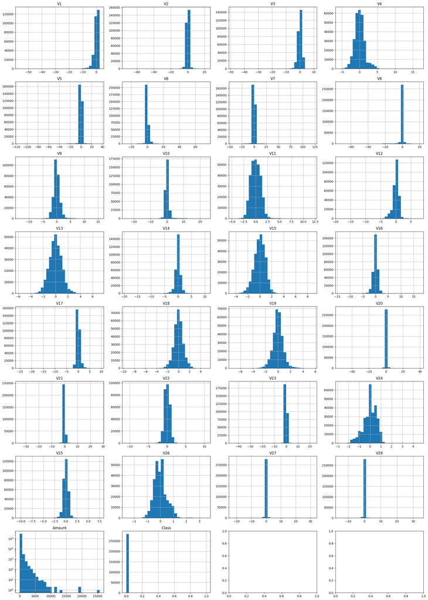

```python
# Features histograms
fig, axes = plt.subplots(8, 4, figsize=(20, 28))  # 8x4 for 29 features + Amount
axes = axes.ravel()

for idx, col in enumerate(df.columns[1:]):  # Skip 'Time', not informative for fraud detection.
    if col == 'Amount':
        # Log scale for Amount (likely right skew)
        df[col].hist(bins=30, ax=axes[idx], log=True)
    else:
        df[col].hist(bins=30, ax=axes[idx])
    axes[idx].set_title(col)

plt.tight_layout()
plt.show()
```

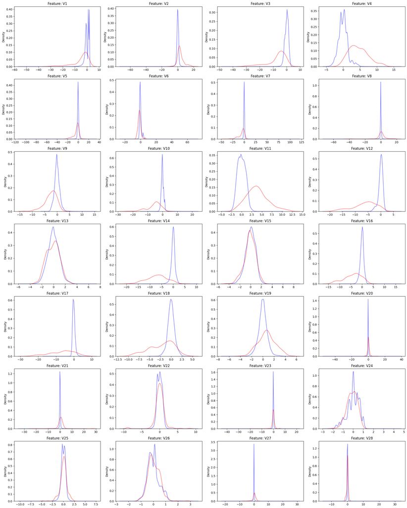

```python
fig, axes = plt.subplots(7, 4, figsize=(20, 25))
axes = axes.ravel()

for idx, col in enumerate(df.columns[1:29]):  # Plot V1-V28 components separately from Time and Class (time assessed separately)
    sns.kdeplot(data=df[df['Class']==0][col], ax=axes[idx], label='Normal', color='blue', alpha=0.5)
    sns.kdeplot(data=df[df['Class']==1][col], ax=axes[idx], label='Fraud', color='red', alpha=0.5)
    axes[idx].set_title(f'Feature: {col}')
    axes[idx].set_xlabel('')

plt.tight_layout()
plt.show()
```

# Exploratory Data Analysis - Credit Card Fraud

## Data Imbalance

- Total transactions: 284,807
- Fraudulent: 492 (0.172%)
- Legitimate: 284,315 (99.828%)

## Feature Distribution Analysis

### PCA Components (V1-V28)

1. Individual Feature Analysis:
   - Most features centered at zero (PCA-transformed)
   - Notable outliers in V14, V12, V10
   - V4, V11, V19 show normal distribution patterns
2. Fraud vs Legitimate Distribution:
   - Strong separation in V4, V11, V14 (distinct peaks for fraud)
   - V24 shows complex multimodal distribution
   - V25, V26 demonstrate similar patterns between classes
   - V1-V3 show clear shifts in distribution between fraud/normal cases

### Amount Distribution

- Highly right-skewed (log scale used)
- Most transactions under 5000
- Several outliers above 20,000

## Key Insights

1. Severe class imbalance requires careful model selection/evaluation
2. Several PCA components show good discriminative power for fraud detection
3. Feature engineering might focus on V4, V11, V14 given their separation patterns

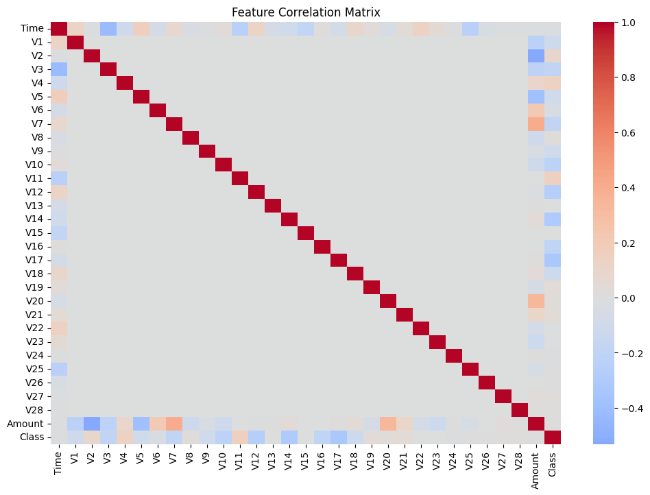

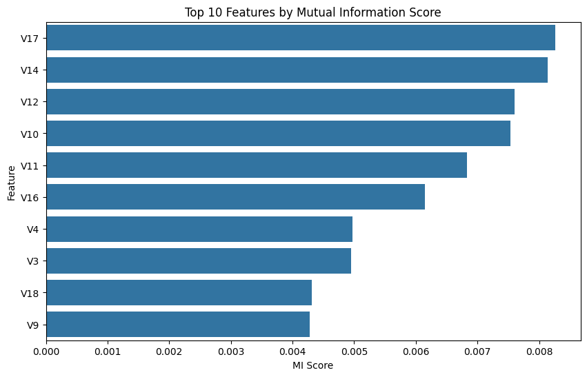

```python
# Correlation matrix
plt.figure(figsize=(12, 8))
sns.heatmap(df.corr(), cmap='coolwarm', center=0)
plt.title('Feature Correlation Matrix')
plt.show()

# Feature importance using mutual information
from sklearn.feature_selection import mutual_info_classif

mi_scores = mutual_info_classif(df.drop('Class', axis=1), df['Class'])
mi_df = pd.DataFrame({'Feature': df.drop('Class', axis=1).columns,
                     'MI Score': mi_scores})
mi_df = mi_df.sort_values('MI Score', ascending=False)

plt.figure(figsize=(10, 6))
sns.barplot(data=mi_df.head(10), x='MI Score', y='Feature')
plt.title('Top 10 Features by Mutual Information Score')
plt.show()
```

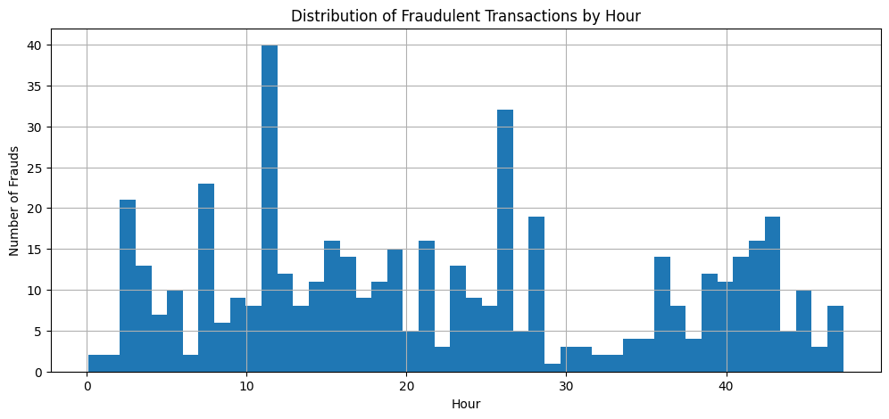

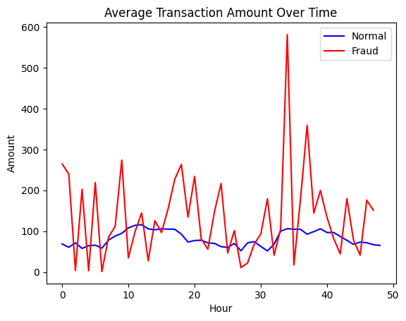

```python
# Convert Time to hours for better visualization
df['Hour'] = df['Time'] / 3600

# Fraud distribution over time
plt.figure(figsize=(12, 5))
fraud_by_hour = df[df['Class']==1]['Hour'].hist(bins=48)
plt.title('Distribution of Fraudulent Transactions by Hour')
plt.xlabel('Hour')
plt.ylabel('Number of Frauds')
plt.show()

# Average amount by class over time
plt.figure(figsize=(12, 5))
df['Hour_Rounded'] = df['Hour'].round()
avg_amount = df.groupby(['Hour_Rounded', 'Class'])['Amount'].mean().unstack()
avg_amount.plot(style=['b-', 'r-'])
plt.title('Average Transaction Amount Over Time')
plt.xlabel('Hour')
plt.ylabel('Amount')
plt.legend(['Normal', 'Fraud'])
plt.show()
```

## Baseline Model Selection

### Preprocessing

1. Train/Val/Test Split: 60/20/20
2. Feature scaling with StandardScaler
3. SMOTE on training data only
4. 5-fold CV for model validation

### Model Choices

1. Logistic Regression
- Simple, interpretable baseline
- class_weight='balanced' for imbalance
2. Random Forest
- Handles nonlinear relationships
- class_weight='balanced'
- n_jobs=-1 for parallel processing
3. XGBoost
- Strong with imbalanced data
- scale_pos_weight for class balance

```python
# Split features and target
X = df.drop('Class', axis=1)
y = df['Class']

# Train-test split with stratification
X_train_full, X_test, y_train_full, y_test = train_test_split(X, y, test_size=0.2, stratify=y, random_state=42)
X_train, X_val, y_train, y_val = train_test_split(X_train_full, y_train_full, test_size=0.25, stratify=y_train_full, random_state=42)

# Scale features
scaler = StandardScaler()
X_train_scaled = scaler.fit_transform(X_train)
X_val_scaled = scaler.transform(X_val)
X_test_scaled = scaler.transform(X_test)

# SMOTE only on training data
smote = SMOTE(random_state=42)
X_train_balanced, y_train_balanced = smote.fit_resample(X_train_scaled, y_train)
```

```python
from sklearn.model_selection import cross_val_score
from sklearn.metrics import average_precision_score, roc_auc_score
from sklearn.linear_model import LogisticRegression
from sklearn.ensemble import RandomForestClassifier
import xgboost as xgb

# Base models with CV
models = {
   'logistic': LogisticRegression(class_weight='balanced'),
   'rf': RandomForestClassifier(class_weight='balanced', n_jobs=-1),
   'xgb': xgb.XGBClassifier(scale_pos_weight=len(y_train_balanced[y_train_balanced==0])/len(y_train_balanced[y_train_balanced==1]))
}

# CV scores
for name, model in models.items():
   cv_scores = cross_val_score(model, X_train_balanced, y_train_balanced, cv=5, scoring='average_precision')
   print(f"{name} CV AUPRC: {cv_scores.mean():.3f} (+/- {cv_scores.std()*2:.3f})")

   # Fit on full training data
   model.fit(X_train_balanced, y_train_balanced)

   # Validation scores
   val_pred = model.predict_proba(X_val_scaled)[:, 1]
   print(f"{name} Validation AUPRC: {average_precision_score(y_val, val_pred):.3f}")
   print(f"{name} Validation ROC-AUC: {roc_auc_score(y_val, val_pred):.3f}\n")
```

```
logistic CV AUPRC: 0.995 (+/- 0.000)
logistic Validation AUPRC: 0.674
logistic Validation ROC-AUC: 0.972

rf CV AUPRC: 1.000 (+/- 0.000)
rf Validation AUPRC: 0.804
rf Validation ROC-AUC: 0.963

xgb CV AUPRC: 1.000 (+/- 0.000)
xgb Validation AUPRC: 0.806
xgb Validation ROC-AUC: 0.967
```

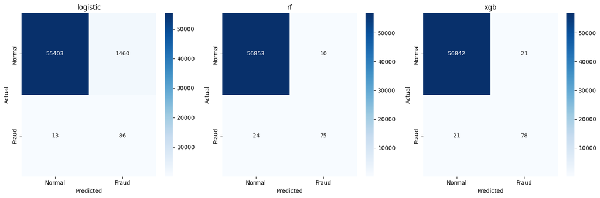

```
logistic:
Missed Frauds (FN): 13
False Alerts (FP): 1460
Detection Rate: 86.87%
False Alert Rate: 2.57%

rf:
Missed Frauds (FN): 24
False Alerts (FP): 10
Detection Rate: 75.76%
False Alert Rate: 0.02%

xgb:
Missed Frauds (FN): 21
False Alerts (FP): 21
Detection Rate: 78.79%
False Alert Rate: 0.04%
```

```python
# import confusion matrix
from sklearn.metrics import confusion_matrix

# Plot Confusion Matrices
fig, axes = plt.subplots(1, 3, figsize=(15, 5))

for idx, (name, model) in enumerate(models.items()):
    y_pred = model.predict(X_val_scaled)
    conf_matrix = confusion_matrix(y_val, y_pred)

    sns.heatmap(conf_matrix, annot=True, fmt="d", cmap="Blues",
                xticklabels=["Normal", "Fraud"],
                yticklabels=["Normal", "Fraud"],
                ax=axes[idx])
    axes[idx].set_title(f"{name}")
    axes[idx].set_xlabel("Predicted")
    axes[idx].set_ylabel("Actual")

plt.tight_layout()
plt.show()

# Fraud-specific metrics
for name, model in models.items():
    y_pred = model.predict(X_val_scaled)
    conf_mat = confusion_matrix(y_val, y_pred)
    tn, fp, fn, tp = conf_mat.ravel()

    print(f"\n{name}:")
    print(f"Missed Frauds (FN): {fn}")
    print(f"False Alerts (FP): {fp}")
    print(f"Detection Rate: {tp/(tp+fn):.2%}")
    print(f"False Alert Rate: {fp/(fp+tn):.2%}")
```

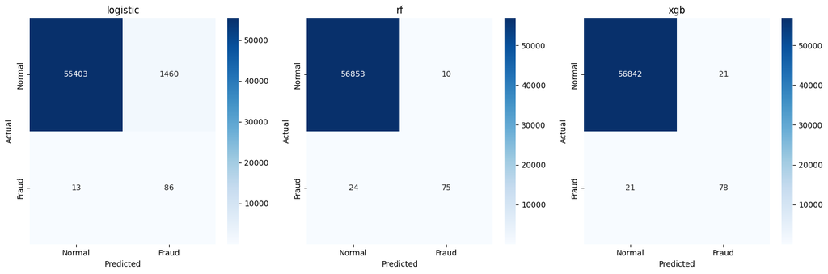

```
logistic:
Missed Frauds (FN): 13
False Alerts (FP): 1460
Detection Rate: 86.87%
False Alert Rate: 2.57%
F1 Score: 0.105

rf:
Missed Frauds (FN): 24
False Alerts (FP): 10
Detection Rate: 75.76%
False Alert Rate: 0.02%
F1 Score: 0.815

xgb:
Missed Frauds (FN): 21
False Alerts (FP): 21
Detection Rate: 78.79%
False Alert Rate: 0.04%
F1 Score: 0.788
```

```python
from sklearn.metrics import confusion_matrix
from sklearn.metrics import f1_score, precision_score, recall_score

# Plot Confusion Matrices
fig, axes = plt.subplots(1, 3, figsize=(15, 5))

for idx, (name, model) in enumerate(models.items()):
    y_pred = model.predict(X_val_scaled)
    conf_matrix = confusion_matrix(y_val, y_pred)

    sns.heatmap(conf_matrix, annot=True, fmt="d", cmap="Blues",
                xticklabels=["Normal", "Fraud"],
                yticklabels=["Normal", "Fraud"],
                ax=axes[idx])
    axes[idx].set_title(f"{name}")
    axes[idx].set_xlabel("Predicted")
    axes[idx].set_ylabel("Actual")

plt.tight_layout()
plt.show()

for name, model in models.items():
    y_pred = model.predict(X_val_scaled)
    conf_mat = confusion_matrix(y_val, y_pred)
    tn, fp, fn, tp = conf_mat.ravel()

    print(f"\n{name}:")
    print(f"Missed Frauds (FN): {fn}")
    print(f"False Alerts (FP): {fp}")
    print(f"Detection Rate: {tp/(tp+fn):.2%}")
    print(f"False Alert Rate: {fp/(fp+tn):.2%}")
    print(f"F1 Score: {f1_score(y_val, y_pred):.3f}")
```

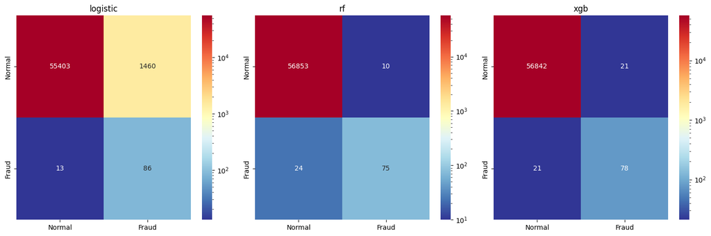

```python
# import Log Norm
from matplotlib.colors import LogNorm

# Modified confusion matrix plot
fig, axes = plt.subplots(1, 3, figsize=(15, 5))

for idx, (name, model) in enumerate(models.items()):
    y_pred = model.predict(X_val_scaled)
    conf_matrix = confusion_matrix(y_val, y_pred)

    sns.heatmap(conf_matrix, annot=True, fmt="d", cmap="RdYlBu_r",
                xticklabels=["Normal", "Fraud"],
                yticklabels=["Normal", "Fraud"],
                ax=axes[idx],
                norm=LogNorm())  # Log scale for better visibility
    axes[idx].set_title(f"{name}")

plt.tight_layout()
plt.show()
```

## Model Evaluation & Results

### Performance Metrics Summary

[output not shown]

### Business Recommendations

```python
from sklearn.model_selection import GridSearchCV

# Store best parameters during grid search
best_params = {}
best_scores = {}

# RF parameters
rf_params = {
    'n_estimators': [100, 200],
    'max_depth': [10, 20, None],
    'min_samples_split': [2, 5],
    'class_weight': ['balanced']
}

# XGB parameters
xgb_params = {
    'max_depth': [3, 5, 7],
    'learning_rate': [0.01, 0.1],
    'n_estimators': [100, 200],
    'scale_pos_weight': [len(y_train[y_train==0])/len(y_train[y_train==1])]
}

# Grid search and store results
for name, (model, params) in {'rf': (RandomForestClassifier(), rf_params),
                             'xgb': (xgb.XGBClassifier(), xgb_params)}.items():
    grid = GridSearchCV(model, params, scoring='average_precision', cv=5)
    grid.fit(X_train_scaled, y_train)
    best_params[name] = grid.best_params_
    best_scores[name] = grid.best_score_
    print(f"\n{name} Best params:", grid.best_params_)
    print(f"Best AUPRC: {grid.best_score_:.3f}")

# Create and evaluate tuned models
models_tuned = {
    'RF (tuned)': RandomForestClassifier(**best_params['rf']),
    'XGB (tuned)': xgb.XGBClassifier(**best_params['xgb'])
}
```

```
rf Best params: {'class_weight': 'balanced', 'max_depth': None, 'min_samples_split': 2, 'n_estimators': 200}
Best AUPRC: 0.849

xgb Best params: {'learning_rate': 0.1, 'max_depth': 7, 'n_estimators': 200, 'scale_pos_weight': 578.264406779661}
Best AUPRC: 0.854
```

```python
# Evaluate tuned models
for name, model in models_tuned.items():
    model.fit(X_train_scaled, y_train)
    y_pred = model.predict(X_val_scaled)
    y_pred_proba = model.predict_proba(X_val_scaled)[:, 1]

    # Calculate metrics
    f1 = f1_score(y_val, y_pred)
    auprc = average_precision_score(y_val, y_pred_proba)
    roc_auc = roc_auc_score(y_val, y_pred_proba)
    tn, fp, fn, tp = confusion_matrix(y_val, y_pred).ravel()

    print(f"\n{name}:")
    print(f"F1 Score: {f1:.3f}")
    print(f"AUPRC: {auprc:.3f}")
    print(f"ROC-AUC: {roc_auc:.3f}")
    print(f"Detection Rate: {tp/(tp+fn):.2%}")
    print(f"False Alert Rate: {fp/(fp+tn):.2%}")
```

```
RF (tuned):
F1 Score: 0.814
AUPRC: 0.807
ROC-AUC: 0.947
Detection Rate: 70.71%
False Alert Rate: 0.01%

XGB (tuned):
F1 Score: 0.831
AUPRC: 0.817
ROC-AUC: 0.977
Detection Rate: 76.77%
False Alert Rate: 0.01%
```

## Model Development and Evaluation

### Initial Model Performance (Validation Set)

[output not shown]

### Hyperparameter Tuning Results (Validation Set)

| Model | Detection Rate | False Alert Rate | F1 Score | AUPRC | ROC AUC |
| --- | --- | --- | --- | --- | --- |
| RF (tuned) | 70.71% | 0.01% | 0.814 | 0.807 | 0.947 |
| XGB (tuned) | 76.77% | 0.01% | 0.831 | 0.817 | 0.977 |

### Model Selection

- XGBoost selected as final model based on:
  - Highest F1 score after tuning (0.831)
  - Best AUPRC (0.817)
  - Optimal balance of detection rate and false alerts

```python
# import XGBClssifier
from xgboost import XGBClassifier

# Get our best XGB model
final_model = XGBClassifier(**best_params['xgb'])
final_model.fit(X_train_scaled, y_train)

# Test set predictions
y_test_pred = final_model.predict(X_test_scaled)
y_test_pred_proba = final_model.predict_proba(X_test_scaled)[:, 1]

# Calculate all metrics
test_f1 = f1_score(y_test, y_test_pred)
test_auprc = average_precision_score(y_test, y_test_pred_proba)
test_roc_auc = roc_auc_score(y_test, y_test_pred_proba)
tn, fp, fn, tp = confusion_matrix(y_test, y_test_pred).ravel()

print("Final XGBoost Performance on Test Set:")
print(f"F1 Score: {test_f1:.3f}")
print(f"AUPRC: {test_auprc:.3f}")
print(f"ROC-AUC: {test_roc_auc:.3f}")
print(f"Detection Rate: {tp/(tp+fn):.2%}")
print(f"False Alert Rate: {fp/(fp+tn):.2%}")
print(f"\nDetailed Counts:")
print(f"True Positives (Caught Frauds): {tp}")
print(f"False Negatives (Missed Frauds): {fn}")
print(f"False Positives (False Alerts): {fp}")
print(f"True Negatives (Correct Normals): {tn}")
```

```
Final XGBoost Performance on Test Set:
F1 Score: 0.848
AUPRC: 0.873
ROC-AUC: 0.978
Detection Rate: 82.65%
False Alert Rate: 0.02%

Detailed Counts:
True Positives (Caught Frauds): 81
False Negatives (Missed Frauds): 17
False Positives (False Alerts): 12
True Negatives (Correct Normals): 56852
```

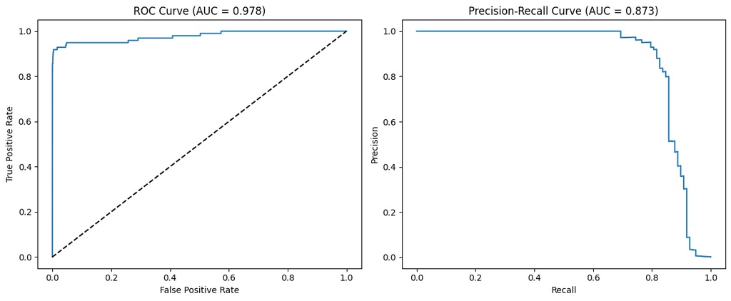

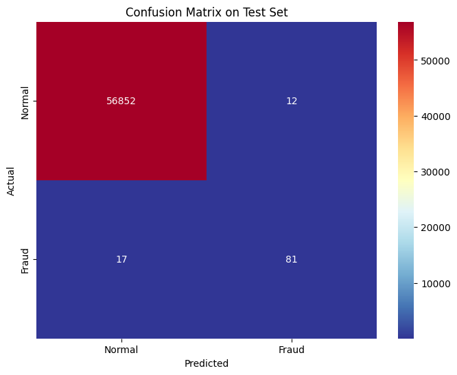

```python
import matplotlib.pyplot as plt
from sklearn.metrics import precision_recall_curve, roc_curve

# Create ROC Curve
fpr, tpr, _ = roc_curve(y_test, y_test_pred_proba)
# Create PR Curve
precision, recall, _ = precision_recall_curve(y_test, y_test_pred_proba)

# Plot both curves
fig, (ax1, ax2) = plt.subplots(1, 2, figsize=(12, 5))

# ROC Curve
ax1.plot(fpr, tpr)
ax1.plot([0, 1], [0, 1], 'k--')  # diagonal line
ax1.set_xlabel('False Positive Rate')
ax1.set_ylabel('True Positive Rate')
ax1.set_title(f'ROC Curve (AUC = {test_roc_auc:.3f})')

# PR Curve
ax2.plot(recall, precision)
ax2.set_xlabel('Recall')
ax2.set_ylabel('Precision')
ax2.set_title(f'Precision-Recall Curve (AUC = {test_auprc:.3f})')

plt.tight_layout()
plt.show()

# Also plot confusion matrix with better visibility
plt.figure(figsize=(8, 6))
sns.heatmap(confusion_matrix(y_test, y_test_pred),
           annot=True,
           fmt='d',
           cmap='RdYlBu_r',
           xticklabels=['Normal', 'Fraud'],
           yticklabels=['Normal', 'Fraud'])
plt.title('Confusion Matrix on Test Set')
plt.xlabel('Predicted')
plt.ylabel('Actual')
plt.show()
```

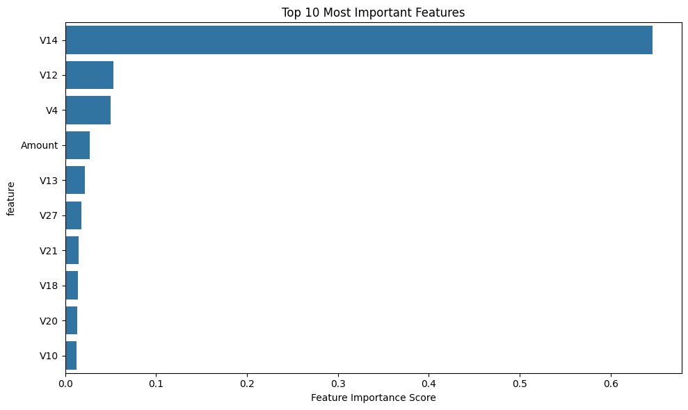

```python
# Get feature importance
importance = final_model.feature_importances_
# Create dataframe of features and their importance scores
feat_imp = pd.DataFrame({
    'feature': X_train.columns,
    'importance': importance
})
feat_imp = feat_imp.sort_values('importance', ascending=False)

# Plot top 10 features
plt.figure(figsize=(10, 6))
sns.barplot(data=feat_imp.head(10), x='importance', y='feature')
plt.title('Top 10 Most Important Features')
plt.xlabel('Feature Importance Score')
plt.tight_layout()
plt.show()
```

## Final Model Performance (Test Set)

### Overall Metrics

| Metric | Value |
| --- | --- |
| F1 Score | 0.848 |
| AUPRC | 0.873 |
| ROC-AUC | 0.978 |
| Detection Rate | 82.65% |
| False Alert Rate | 0.02% |

### Detailed Performance

- **Fraud Detection**
  - Successfully caught: 81 fraudulent transactions
  - Missed: 17 fraudulent transactions
  - Detection rate shows model catches ~83% of frauds
- **False Alerts**
  - False alerts generated: 12
  - Out of 56,864 normal transactions
  - Very low false alert rate (0.02%)

### Model Characteristics

1. **Strong Discrimination** (ROC-AUC = 0.978)
   - Excellent separation between fraud/normal transactions
   - Sharp curve in ROC plot indicates high true positive rate with low false positives
2. **Precision-Recall Performance** (AUPRC = 0.873)
   - Maintains high precision until ~80% recall
   - Sharp drop after 80% recall indicates confidence threshold
3. **Operational Impact**
   - Only 12 false alerts per ~57,000 transactions
   - 17 missed frauds might need investigation of common patterns

## Business Recommendations

1. Model Performance & Implementation
- Deploy XGBoost model with proven 82.65% fraud detection rate
- Extremely low false alert burden (12 per 57,000 transactions)
- Set up real-time monitoring system prioritizing V14, V12, and V4 features
2. Feature-Based Strategy
- Primary focus on V14 as dominant indicator
  - Monitor this feature closely for stability
  - Consider building backup models if V14 becomes compromised
- Use V12 and V4 as supporting indicators
- Monitor transaction amounts as key non-PCA feature
- Consider developing specialized models for high-amount transactions
3. Risk Management
- Investigate 17 missed frauds focusing on:
  - Patterns in V14 values
  - Unusual combinations of top features
- Set alert thresholds based on feature importance
- Consider lower thresholds when V14 shows suspicious patterns

# Conclusion

## Project Summary

This project developed a credit card fraud detection system using machine learning, addressing a significant class imbalance (0.172% fraud cases). Through systematic evaluation of multiple models and careful tuning, we achieved a robust fraud detection solution.

## Key Achievements

1. **Model Performance**
   - 82.65% fraud detection rate
   - Only 0.02% false alert rate
   - Strong AUPRC (0.873) and ROC-AUC (0.978)
2. **Operational Efficiency**
   - 81 out of 98 frauds detected
   - Only 12 false alerts per 57,000 transactions
   - Clear feature importance hierarchy for investigation
3. **Business Value**
   - Manageable investigation workload
   - Data-driven fraud detection process
   - Balance between detection and operational efficiency

## Limitations and Future Work

1. **Model Limitations**
   - 17 undetected frauds require pattern analysis
   - Heavy reliance on V14 feature
   - PCA transformation limits feature interpretability
2. **Future Improvements**
   - Explore deep learning approaches
   - Investigate temporal patterns in missed frauds
   - Develop ensemble methods for robust detection
   - Consider cost-sensitive learning based on transaction amounts

## Final Thoughts

The developed solution provides a practical balance between fraud detection and operational efficiency. While not perfect, it offers a solid foundation for protecting against credit card fraud while maintaining manageable false alert rates.